# Risk Factor Analysis

## Outcome Variable

**Outcome Variable:** wasted

## Predictor Variables

**Intervention Variable:** gagebrth

**Adjustment Set:**

- arm
- sex
- W_mage
- meducyrs
- feducyrs
- hhwealth_quart
- single
- brthmon
- W_parity
- delta_W_mage
- delta_meducyrs
- delta_feducyrs
- delta_hhwealth_quart
- delta_single
- delta_brthmon
- delta_W_parity

## Stratifying Variables

The analysis was stratified on these variable(s):

- agecat
- studyid
- country

## Data Summary

| agecat | studyid | country | gagebrth | wasted | n_cell | n |
| --- | --- | --- | --- | --- | --- | --- |
| Birth | ki1000108-CMC-V-BCS-2002 | INDIA | Full or late term | 0 | 46 | 87 |
| Birth | ki1000108-CMC-V-BCS-2002 | INDIA | Full or late term | 1 | 8 | 87 |
| Birth | ki1000108-CMC-V-BCS-2002 | INDIA | Preterm | 0 | 8 | 87 |
| Birth | ki1000108-CMC-V-BCS-2002 | INDIA | Preterm | 1 | 2 | 87 |
| Birth | ki1000108-CMC-V-BCS-2002 | INDIA | Early term | 0 | 20 | 87 |
| Birth | ki1000108-CMC-V-BCS-2002 | INDIA | Early term | 1 | 3 | 87 |
| Birth | ki1000108-IRC | INDIA | Full or late term | 0 | 164 | 328 |
| Birth | ki1000108-IRC | INDIA | Full or late term | 1 | 49 | 328 |
| Birth | ki1000108-IRC | INDIA | Preterm | 0 | 19 | 328 |
| Birth | ki1000108-IRC | INDIA | Preterm | 1 | 13 | 328 |
| Birth | ki1000108-IRC | INDIA | Early term | 0 | 58 | 328 |
| Birth | ki1000108-IRC | INDIA | Early term | 1 | 25 | 328 |
| Birth | ki1000109-EE | PAKISTAN | Full or late term | 0 | 0 | 1 |
| Birth | ki1000109-EE | PAKISTAN | Full or late term | 1 | 0 | 1 |
| Birth | ki1000109-EE | PAKISTAN | Preterm | 0 | 1 | 1 |
| Birth | ki1000109-EE | PAKISTAN | Preterm | 1 | 0 | 1 |
| Birth | ki1000109-EE | PAKISTAN | Early term | 0 | 0 | 1 |
| Birth | ki1000109-EE | PAKISTAN | Early term | 1 | 0 | 1 |
| Birth | ki1000304b-SAS-CompFeed | INDIA | Full or late term | 0 | 1 | 166 |
| Birth | ki1000304b-SAS-CompFeed | INDIA | Full or late term | 1 | 0 | 166 |
| Birth | ki1000304b-SAS-CompFeed | INDIA | Preterm | 0 | 141 | 166 |
| Birth | ki1000304b-SAS-CompFeed | INDIA | Preterm | 1 | 10 | 166 |
| Birth | ki1000304b-SAS-CompFeed | INDIA | Early term | 0 | 13 | 166 |
| Birth | ki1000304b-SAS-CompFeed | INDIA | Early term | 1 | 1 | 166 |
| Birth | ki1017093c-NIH-Crypto | BANGLADESH | Full or late term | 0 | 5 | 23 |
| Birth | ki1017093c-NIH-Crypto | BANGLADESH | Full or late term | 1 | 1 | 23 |
| Birth | ki1017093c-NIH-Crypto | BANGLADESH | Preterm | 0 | 2 | 23 |
| Birth | ki1017093c-NIH-Crypto | BANGLADESH | Preterm | 1 | 1 | 23 |
| Birth | ki1017093c-NIH-Crypto | BANGLADESH | Early term | 0 | 13 | 23 |
| Birth | ki1017093c-NIH-Crypto | BANGLADESH | Early term | 1 | 1 | 23 |

[output cut: 168 more lines]

The following strata were considered:

- agecat: 24 months, studyid: ki1000108-CMC-V-BCS-2002, country: INDIA
- agecat: 24 months, studyid: ki1000108-IRC, country: INDIA
- agecat: 24 months, studyid: ki1017093c-NIH-Crypto, country: BANGLADESH
- agecat: 24 months, studyid: ki1066203-TanzaniaChild2, country: TANZANIA, UNITED REPUBLIC OF
- agecat: 24 months, studyid: ki1101329-Keneba, country: GAMBIA
- agecat: 24 months, studyid: ki1119695-PROBIT, country: BELARUS
- agecat: 24 months, studyid: ki1135781-COHORTS, country: GUATEMALA
- agecat: 24 months, studyid: ki1135781-COHORTS, country: INDIA
- agecat: 24 months, studyid: ki1135781-COHORTS, country: PHILIPPINES
- agecat: 24 months, studyid: kiGH5241-JiVitA-3, country: BANGLADESH
- agecat: 6 months, studyid: ki1000108-CMC-V-BCS-2002, country: INDIA
- agecat: 6 months, studyid: ki1000108-IRC, country: INDIA
- agecat: 6 months, studyid: ki1000109-EE, country: PAKISTAN
- agecat: 6 months, studyid: ki1000304b-SAS-CompFeed, country: INDIA
- agecat: 6 months, studyid: ki1017093c-NIH-Crypto, country: BANGLADESH
- agecat: 6 months, studyid: ki1066203-TanzaniaChild2, country: TANZANIA, UNITED REPUBLIC OF
- agecat: 6 months, studyid: ki1101329-Keneba, country: GAMBIA
- agecat: 6 months, studyid: ki1119695-PROBIT, country: BELARUS
- agecat: 6 months, studyid: ki1135781-COHORTS, country: GUATEMALA
- agecat: 6 months, studyid: ki1135781-COHORTS, country: INDIA
- agecat: 6 months, studyid: ki1135781-COHORTS, country: PHILIPPINES
- agecat: 6 months, studyid: kiGH5241-JiVitA-3, country: BANGLADESH
- agecat: Birth, studyid: ki1000108-CMC-V-BCS-2002, country: INDIA
- agecat: Birth, studyid: ki1000108-IRC, country: INDIA
- agecat: Birth, studyid: ki1000109-EE, country: PAKISTAN
- agecat: Birth, studyid: ki1000304b-SAS-CompFeed, country: INDIA
- agecat: Birth, studyid: ki1017093c-NIH-Crypto, country: BANGLADESH
- agecat: Birth, studyid: ki1101329-Keneba, country: GAMBIA
- agecat: Birth, studyid: ki1119695-PROBIT, country: BELARUS
- agecat: Birth, studyid: ki1135781-COHORTS, country: GUATEMALA
- agecat: Birth, studyid: ki1135781-COHORTS, country: INDIA
- agecat: Birth, studyid: ki1135781-COHORTS, country: PHILIPPINES
- agecat: Birth, studyid: kiGH5241-JiVitA-3, country: BANGLADESH

### Dropped Strata

Some strata were dropped due to rare outcomes:

- agecat: Birth, studyid: ki1000108-CMC-V-BCS-2002, country: INDIA
- agecat: Birth, studyid: ki1000109-EE, country: PAKISTAN
- agecat: Birth, studyid: ki1000304b-SAS-CompFeed, country: INDIA
- agecat: Birth, studyid: ki1017093c-NIH-Crypto, country: BANGLADESH
- agecat: 6 months, studyid: ki1000109-EE, country: PAKISTAN
- agecat: 6 months, studyid: ki1017093c-NIH-Crypto, country: BANGLADESH
- agecat: 6 months, studyid: ki1135781-COHORTS, country: GUATEMALA
- agecat: 24 months, studyid: ki1000108-CMC-V-BCS-2002, country: INDIA
- agecat: 24 months, studyid: ki1017093c-NIH-Crypto, country: BANGLADESH
- agecat: 24 months, studyid: ki1066203-TanzaniaChild2, country: TANZANIA, UNITED REPUBLIC OF
- agecat: 24 months, studyid: ki1119695-PROBIT, country: BELARUS

## Methods Detail

We’re interested in the causal parameters $E[Y_a]$ for all values of $a \in \mathcal{A}$. These parameters represent the mean outcome if, possibly contrary to fact, we intervened to set all units to have $A=a$. Under the randomization and positivity assumptions, these are identified by the statistical parameters $\psi_a=E_W[E_{Y|A,W}(Y|A=a,W)]$. In addition, we’re interested in the mean of $Y$, $E[Y]$ under no intervention (the observed mean). We will estimate these parameters by using SuperLearner to fit the relevant likelihood factors – $E_{Y|A,W}(Y|A=a,W)$ and $p(A=a|W)$, and then updating our likelihood fit using a joint TMLE.

For unadjusted analyses ($W=\{\}$), initial likelihoods were estimated using Lrnr_glm to estimate the simple $E(Y|A)$ and Lrnr_mean to estimate $p(A)$. For adjusted analyses, a small library containing Lrnr_glmnet, Lrnr_xgboost, and Lrnr_mean was used.

Having estimated these parameters, we will then use the delta method to estimate relative risks and attributable risks relative to a prespecified baseline level of $A$.

# Results Detail

## Results Plots

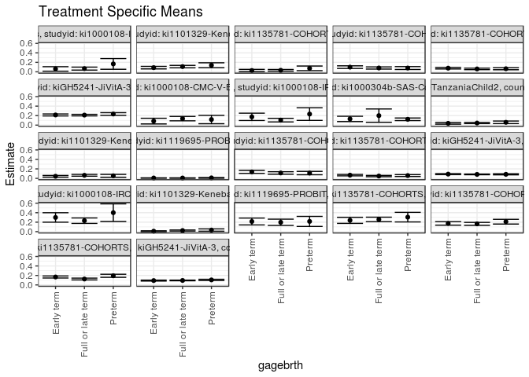

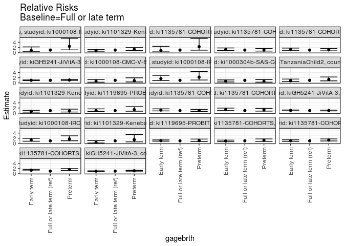

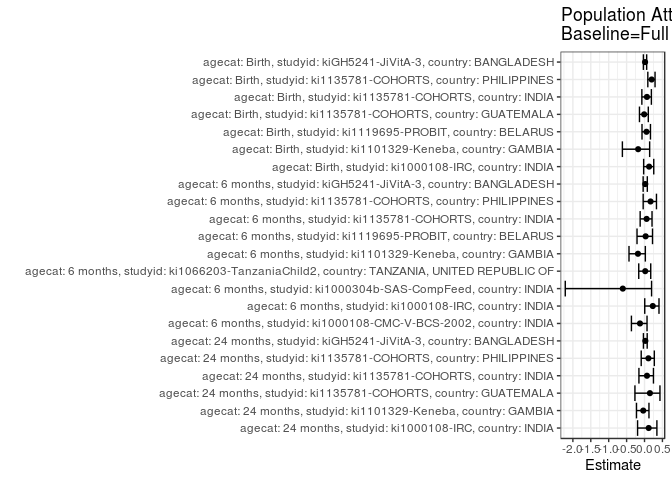

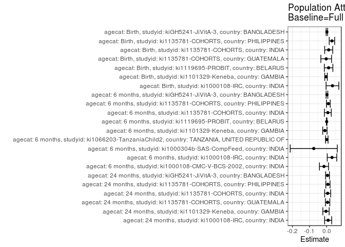

## Results Table

### Parameter: TSM

| agecat | studyid | country | intervention_level | baseline_level | estimate | ci_lower | ci_upper |
| --- | --- | --- | --- | --- | --- | --- | --- |
| Birth | ki1000108-IRC | INDIA | Full or late term | NA | 0.2312810 | 0.1737233 | 0.2888388 |
| Birth | ki1000108-IRC | INDIA | Preterm | NA | 0.4000807 | 0.2142481 | 0.5859133 |
| Birth | ki1000108-IRC | INDIA | Early term | NA | 0.2992905 | 0.1990504 | 0.3995305 |
| Birth | ki1101329-Keneba | GAMBIA | Full or late term | NA | 0.0235294 | 0.0121326 | 0.0349262 |
| Birth | ki1101329-Keneba | GAMBIA | Preterm | NA | 0.0338164 | 0.0091837 | 0.0584491 |
| Birth | ki1101329-Keneba | GAMBIA | Early term | NA | 0.0097276 | 0.0012397 | 0.0182156 |
| Birth | ki1119695-PROBIT | BELARUS | Full or late term | NA | 0.1973746 | 0.1313735 | 0.2633757 |
| Birth | ki1119695-PROBIT | BELARUS | Preterm | NA | 0.2159794 | 0.1098450 | 0.3221138 |
| Birth | ki1119695-PROBIT | BELARUS | Early term | NA | 0.2144832 | 0.1423570 | 0.2866094 |
| Birth | ki1135781-COHORTS | GUATEMALA | Full or late term | NA | 0.2578189 | 0.2101729 | 0.3054648 |
| Birth | ki1135781-COHORTS | GUATEMALA | Preterm | NA | 0.3056850 | 0.2046660 | 0.4067040 |
| Birth | ki1135781-COHORTS | GUATEMALA | Early term | NA | 0.2386274 | 0.1744534 | 0.3028014 |
| Birth | ki1135781-COHORTS | INDIA | Full or late term | NA | 0.1645338 | 0.1336864 | 0.1953812 |
| Birth | ki1135781-COHORTS | INDIA | Preterm | NA | 0.2102054 | 0.1600522 | 0.2603587 |
| Birth | ki1135781-COHORTS | INDIA | Early term | NA | 0.1735586 | 0.1369634 | 0.2101537 |
| Birth | ki1135781-COHORTS | PHILIPPINES | Full or late term | NA | 0.1245225 | 0.1055045 | 0.1435406 |
| Birth | ki1135781-COHORTS | PHILIPPINES | Preterm | NA | 0.1929288 | 0.1607840 | 0.2250735 |
| Birth | ki1135781-COHORTS | PHILIPPINES | Early term | NA | 0.1675262 | 0.1459471 | 0.1891053 |
| Birth | kiGH5241-JiVitA-3 | BANGLADESH | Full or late term | NA | 0.0946179 | 0.0878140 | 0.1014218 |
| Birth | kiGH5241-JiVitA-3 | BANGLADESH | Preterm | NA | 0.1062918 | 0.0933495 | 0.1192342 |
| Birth | kiGH5241-JiVitA-3 | BANGLADESH | Early term | NA | 0.0920932 | 0.0825055 | 0.1016809 |
| 6 months | ki1000108-CMC-V-BCS-2002 | INDIA | Full or late term | NA | 0.1367925 | 0.0904694 | 0.1831155 |
| 6 months | ki1000108-CMC-V-BCS-2002 | INDIA | Preterm | NA | 0.1176471 | 0.0290941 | 0.2062000 |
| 6 months | ki1000108-CMC-V-BCS-2002 | INDIA | Early term | NA | 0.0843373 | 0.0244665 | 0.1442082 |
| 6 months | ki1000108-IRC | INDIA | Full or late term | NA | 0.1051246 | 0.0668955 | 0.1433537 |
| 6 months | ki1000108-IRC | INDIA | Preterm | NA | 0.2328309 | 0.0992307 | 0.3664310 |
| 6 months | ki1000108-IRC | INDIA | Early term | NA | 0.1740082 | 0.0968511 | 0.2511654 |
| 6 months | ki1000304b-SAS-CompFeed | INDIA | Full or late term | NA | 0.2000000 | 0.0598640 | 0.3401360 |
| 6 months | ki1000304b-SAS-CompFeed | INDIA | Preterm | NA | 0.1225166 | 0.0952376 | 0.1497956 |
| 6 months | ki1000304b-SAS-CompFeed | INDIA | Early term | NA | 0.1304348 | 0.0742562 | 0.1866133 |
| 6 months | ki1066203-TanzaniaChild2 | TANZANIA, UNITED REPUBLIC OF | Full or late term | NA | 0.0437873 | 0.0320196 | 0.0555550 |
| 6 months | ki1066203-TanzaniaChild2 | TANZANIA, UNITED REPUBLIC OF | Preterm | NA | 0.0588191 | 0.0315324 | 0.0861059 |
| 6 months | ki1066203-TanzaniaChild2 | TANZANIA, UNITED REPUBLIC OF | Early term | NA | 0.0376585 | 0.0199590 | 0.0553580 |
| 6 months | ki1101329-Keneba | GAMBIA | Full or late term | NA | 0.0654582 | 0.0465588 | 0.0843576 |
| 6 months | ki1101329-Keneba | GAMBIA | Preterm | NA | 0.0543898 | 0.0240376 | 0.0847420 |
| 6 months | ki1101329-Keneba | GAMBIA | Early term | NA | 0.0439546 | 0.0262306 | 0.0616785 |
| 6 months | ki1119695-PROBIT | BELARUS | Full or late term | NA | 0.0079950 | 0.0052987 | 0.0106913 |
| 6 months | ki1119695-PROBIT | BELARUS | Preterm | NA | 0.0108893 | 0.0041768 | 0.0176017 |
| 6 months | ki1119695-PROBIT | BELARUS | Early term | NA | 0.0083322 | 0.0061258 | 0.0105385 |
| 6 months | ki1135781-COHORTS | INDIA | Full or late term | NA | 0.1140997 | 0.0878436 | 0.1403558 |
| 6 months | ki1135781-COHORTS | INDIA | Preterm | NA | 0.1118141 | 0.0761432 | 0.1474851 |
| 6 months | ki1135781-COHORTS | INDIA | Early term | NA | 0.1369587 | 0.1052462 | 0.1686713 |
| 6 months | ki1135781-COHORTS | PHILIPPINES | Full or late term | NA | 0.0492463 | 0.0359659 | 0.0625268 |
| 6 months | ki1135781-COHORTS | PHILIPPINES | Preterm | NA | 0.0596076 | 0.0402076 | 0.0790077 |
| 6 months | ki1135781-COHORTS | PHILIPPINES | Early term | NA | 0.0683263 | 0.0533369 | 0.0833157 |
| 6 months | kiGH5241-JiVitA-3 | BANGLADESH | Full or late term | NA | 0.0842429 | 0.0769616 | 0.0915243 |
| 6 months | kiGH5241-JiVitA-3 | BANGLADESH | Preterm | NA | 0.0858032 | 0.0740432 | 0.0975632 |
| 6 months | kiGH5241-JiVitA-3 | BANGLADESH | Early term | NA | 0.0899110 | 0.0791707 | 0.1006513 |
| 24 months | ki1000108-IRC | INDIA | Full or late term | NA | 0.0680000 | 0.0367537 | 0.0992463 |
| 24 months | ki1000108-IRC | INDIA | Preterm | NA | 0.1666667 | 0.0538133 | 0.2795201 |
| 24 months | ki1000108-IRC | INDIA | Early term | NA | 0.0612245 | 0.0136980 | 0.1087510 |
| 24 months | ki1101329-Keneba | GAMBIA | Full or late term | NA | 0.1100868 | 0.0839699 | 0.1362037 |
| 24 months | ki1101329-Keneba | GAMBIA | Preterm | NA | 0.1383993 | 0.0861503 | 0.1906483 |
| 24 months | ki1101329-Keneba | GAMBIA | Early term | NA | 0.0883054 | 0.0615069 | 0.1151040 |
| 24 months | ki1135781-COHORTS | GUATEMALA | Full or late term | NA | 0.0318302 | 0.0140966 | 0.0495639 |
| 24 months | ki1135781-COHORTS | GUATEMALA | Preterm | NA | 0.0733945 | 0.0244008 | 0.1223881 |
| 24 months | ki1135781-COHORTS | GUATEMALA | Early term | NA | 0.0276243 | 0.0037298 | 0.0515188 |
| 24 months | ki1135781-COHORTS | INDIA | Full or late term | NA | 0.0810776 | 0.0582394 | 0.1039159 |
| 24 months | ki1135781-COHORTS | INDIA | Preterm | NA | 0.0800585 | 0.0494727 | 0.1106443 |
| 24 months | ki1135781-COHORTS | INDIA | Early term | NA | 0.0989073 | 0.0709873 | 0.1268273 |
| 24 months | ki1135781-COHORTS | PHILIPPINES | Full or late term | NA | 0.0609074 | 0.0455529 | 0.0762619 |
| 24 months | ki1135781-COHORTS | PHILIPPINES | Preterm | NA | 0.0653044 | 0.0440251 | 0.0865837 |
| 24 months | ki1135781-COHORTS | PHILIPPINES | Early term | NA | 0.0773700 | 0.0605729 | 0.0941672 |
| 24 months | kiGH5241-JiVitA-3 | BANGLADESH | Full or late term | NA | 0.2108249 | 0.1943098 | 0.2273399 |
| 24 months | kiGH5241-JiVitA-3 | BANGLADESH | Preterm | NA | 0.2341072 | 0.2063156 | 0.2618988 |
| 24 months | kiGH5241-JiVitA-3 | BANGLADESH | Early term | NA | 0.2138315 | 0.1930552 | 0.2346078 |

### Parameter: E(Y)

| agecat | studyid | country | intervention_level | baseline_level | estimate | ci_lower | ci_upper |
| --- | --- | --- | --- | --- | --- | --- | --- |
| Birth | ki1000108-IRC | INDIA | NA | NA | 0.2652439 | 0.2173954 | 0.3130924 |
| Birth | ki1101329-Keneba | GAMBIA | NA | NA | 0.0199857 | 0.0126548 | 0.0273167 |
| Birth | ki1119695-PROBIT | BELARUS | NA | NA | 0.2089120 | 0.1435514 | 0.2742726 |
| Birth | ki1135781-COHORTS | GUATEMALA | NA | NA | 0.2552448 | 0.2194833 | 0.2910062 |
| Birth | ki1135781-COHORTS | INDIA | NA | NA | 0.1765663 | 0.1552399 | 0.1978927 |
| Birth | ki1135781-COHORTS | PHILIPPINES | NA | NA | 0.1555324 | 0.1422803 | 0.1687844 |
| Birth | kiGH5241-JiVitA-3 | BANGLADESH | NA | NA | 0.0961020 | 0.0908277 | 0.1013762 |
| 6 months | ki1000108-CMC-V-BCS-2002 | INDIA | NA | NA | 0.1213873 | 0.0869266 | 0.1558480 |
| 6 months | ki1000108-IRC | INDIA | NA | NA | 0.1365979 | 0.1023826 | 0.1708133 |
| 6 months | ki1000304b-SAS-CompFeed | INDIA | NA | NA | 0.1245283 | 0.0993306 | 0.1497260 |
| 6 months | ki1066203-TanzaniaChild2 | TANZANIA, UNITED REPUBLIC OF | NA | NA | 0.0446898 | 0.0354016 | 0.0539780 |
| 6 months | ki1101329-Keneba | GAMBIA | NA | NA | 0.0553130 | 0.0432217 | 0.0674042 |
| 6 months | ki1119695-PROBIT | BELARUS | NA | NA | 0.0082503 | 0.0066012 | 0.0098994 |
| 6 months | ki1135781-COHORTS | INDIA | NA | NA | 0.1211890 | 0.1035235 | 0.1388545 |
| 6 months | ki1135781-COHORTS | PHILIPPINES | NA | NA | 0.0592179 | 0.0502884 | 0.0681474 |
| 6 months | kiGH5241-JiVitA-3 | BANGLADESH | NA | NA | 0.0860879 | 0.0805805 | 0.0915953 |
| 24 months | ki1000108-IRC | INDIA | NA | NA | 0.0769231 | 0.0504429 | 0.1034032 |
| 24 months | ki1101329-Keneba | GAMBIA | NA | NA | 0.1063094 | 0.0885410 | 0.1240778 |
| 24 months | ki1135781-COHORTS | GUATEMALA | NA | NA | 0.0374813 | 0.0230560 | 0.0519065 |
| 24 months | ki1135781-COHORTS | INDIA | NA | NA | 0.0870570 | 0.0717143 | 0.1023997 |
| 24 months | ki1135781-COHORTS | PHILIPPINES | NA | NA | 0.0683690 | 0.0583283 | 0.0784097 |
| 24 months | kiGH5241-JiVitA-3 | BANGLADESH | NA | NA | 0.2159196 | 0.2043522 | 0.2274871 |

### Parameter: RR

| agecat | studyid | country | intervention_level | baseline_level | estimate | ci_lower | ci_upper |
| --- | --- | --- | --- | --- | --- | --- | --- |
| Birth | ki1000108-IRC | INDIA | Full or late term | Full or late term | 1.0000000 | 1.0000000 | 1.000000 |
| Birth | ki1000108-IRC | INDIA | Preterm | Full or late term | 1.7298467 | 1.0212359 | 2.930145 |
| Birth | ki1000108-IRC | INDIA | Early term | Full or late term | 1.2940555 | 0.8523167 | 1.964739 |
| Birth | ki1101329-Keneba | GAMBIA | Full or late term | Full or late term | 1.0000000 | 1.0000000 | 1.000000 |
| Birth | ki1101329-Keneba | GAMBIA | Preterm | Full or late term | 1.4371981 | 0.5992553 | 3.446842 |
| Birth | ki1101329-Keneba | GAMBIA | Early term | Full or late term | 0.4134241 | 0.1523972 | 1.121539 |
| Birth | ki1119695-PROBIT | BELARUS | Full or late term | Full or late term | 1.0000000 | 1.0000000 | 1.000000 |
| Birth | ki1119695-PROBIT | BELARUS | Preterm | Full or late term | 1.0942614 | 0.7147507 | 1.675280 |
| Birth | ki1119695-PROBIT | BELARUS | Early term | Full or late term | 1.0866808 | 0.8663211 | 1.363092 |
| Birth | ki1135781-COHORTS | GUATEMALA | Full or late term | Full or late term | 1.0000000 | 1.0000000 | 1.000000 |
| Birth | ki1135781-COHORTS | GUATEMALA | Preterm | Full or late term | 1.1856580 | 0.8113527 | 1.732643 |
| Birth | ki1135781-COHORTS | GUATEMALA | Early term | Full or late term | 0.9255621 | 0.6678472 | 1.282726 |
| Birth | ki1135781-COHORTS | INDIA | Full or late term | Full or late term | 1.0000000 | 1.0000000 | 1.000000 |
| Birth | ki1135781-COHORTS | INDIA | Preterm | Full or late term | 1.2775820 | 0.9440880 | 1.728881 |
| Birth | ki1135781-COHORTS | INDIA | Early term | Full or late term | 1.0548506 | 0.7954207 | 1.398895 |
| Birth | ki1135781-COHORTS | PHILIPPINES | Full or late term | Full or late term | 1.0000000 | 1.0000000 | 1.000000 |
| Birth | ki1135781-COHORTS | PHILIPPINES | Preterm | Full or late term | 1.5493480 | 1.2363473 | 1.941590 |
| Birth | ki1135781-COHORTS | PHILIPPINES | Early term | Full or late term | 1.3453482 | 1.1020614 | 1.642342 |
| Birth | kiGH5241-JiVitA-3 | BANGLADESH | Full or late term | Full or late term | 1.0000000 | 1.0000000 | 1.000000 |
| Birth | kiGH5241-JiVitA-3 | BANGLADESH | Preterm | Full or late term | 1.1233797 | 0.9762088 | 1.292738 |
| Birth | kiGH5241-JiVitA-3 | BANGLADESH | Early term | Full or late term | 0.9733168 | 0.8596292 | 1.102040 |
| 6 months | ki1000108-CMC-V-BCS-2002 | INDIA | Full or late term | Full or late term | 1.0000000 | 1.0000000 | 1.000000 |
| 6 months | ki1000108-CMC-V-BCS-2002 | INDIA | Preterm | Full or late term | 0.8600406 | 0.3767610 | 1.963234 |
| 6 months | ki1000108-CMC-V-BCS-2002 | INDIA | Early term | Full or late term | 0.6165351 | 0.2807839 | 1.353765 |
| 6 months | ki1000108-IRC | INDIA | Full or late term | Full or late term | 1.0000000 | 1.0000000 | 1.000000 |
| 6 months | ki1000108-IRC | INDIA | Preterm | Full or late term | 2.2148097 | 1.1223839 | 4.370503 |
| 6 months | ki1000108-IRC | INDIA | Early term | Full or late term | 1.6552577 | 0.9326525 | 2.937727 |
| 6 months | ki1000304b-SAS-CompFeed | INDIA | Full or late term | Full or late term | 1.0000000 | 1.0000000 | 1.000000 |
| 6 months | ki1000304b-SAS-CompFeed | INDIA | Preterm | Full or late term | 0.6125828 | 0.2912002 | 1.288659 |
| 6 months | ki1000304b-SAS-CompFeed | INDIA | Early term | Full or late term | 0.6521739 | 0.3675930 | 1.157070 |
| 6 months | ki1066203-TanzaniaChild2 | TANZANIA, UNITED REPUBLIC OF | Full or late term | Full or late term | 1.0000000 | 1.0000000 | 1.000000 |
| 6 months | ki1066203-TanzaniaChild2 | TANZANIA, UNITED REPUBLIC OF | Preterm | Full or late term | 1.3432925 | 0.7858227 | 2.296237 |
| 6 months | ki1066203-TanzaniaChild2 | TANZANIA, UNITED REPUBLIC OF | Early term | Full or late term | 0.8600328 | 0.5004416 | 1.478007 |
| 6 months | ki1101329-Keneba | GAMBIA | Full or late term | Full or late term | 1.0000000 | 1.0000000 | 1.000000 |
| 6 months | ki1101329-Keneba | GAMBIA | Preterm | Full or late term | 0.8309095 | 0.4432673 | 1.557549 |
| 6 months | ki1101329-Keneba | GAMBIA | Early term | Full or late term | 0.6714908 | 0.4090094 | 1.102419 |
| 6 months | ki1119695-PROBIT | BELARUS | Full or late term | Full or late term | 1.0000000 | 1.0000000 | 1.000000 |
| 6 months | ki1119695-PROBIT | BELARUS | Preterm | Full or late term | 1.3620122 | 0.7433311 | 2.495627 |
| 6 months | ki1119695-PROBIT | BELARUS | Early term | Full or late term | 1.0421730 | 0.6561487 | 1.655302 |
| 6 months | ki1135781-COHORTS | INDIA | Full or late term | Full or late term | 1.0000000 | 1.0000000 | 1.000000 |
| 6 months | ki1135781-COHORTS | INDIA | Preterm | Full or late term | 0.9799686 | 0.6615248 | 1.451704 |
| 6 months | ki1135781-COHORTS | INDIA | Early term | Full or late term | 1.2003427 | 0.8670199 | 1.661810 |
| 6 months | ki1135781-COHORTS | PHILIPPINES | Full or late term | Full or late term | 1.0000000 | 1.0000000 | 1.000000 |
| 6 months | ki1135781-COHORTS | PHILIPPINES | Preterm | Full or late term | 1.2103975 | 0.7934949 | 1.846341 |
| 6 months | ki1135781-COHORTS | PHILIPPINES | Early term | Full or late term | 1.3874399 | 0.9803917 | 1.963490 |
| 6 months | kiGH5241-JiVitA-3 | BANGLADESH | Full or late term | Full or late term | 1.0000000 | 1.0000000 | 1.000000 |
| 6 months | kiGH5241-JiVitA-3 | BANGLADESH | Preterm | Full or late term | 1.0185206 | 0.8712719 | 1.190655 |
| 6 months | kiGH5241-JiVitA-3 | BANGLADESH | Early term | Full or late term | 1.0672823 | 0.9220365 | 1.235408 |
| 24 months | ki1000108-IRC | INDIA | Full or late term | Full or late term | 1.0000000 | 1.0000000 | 1.000000 |
| 24 months | ki1000108-IRC | INDIA | Preterm | Full or late term | 2.4509804 | 1.0813122 | 5.555569 |
| 24 months | ki1000108-IRC | INDIA | Early term | Full or late term | 0.9003601 | 0.3653015 | 2.219121 |
| 24 months | ki1101329-Keneba | GAMBIA | Full or late term | Full or late term | 1.0000000 | 1.0000000 | 1.000000 |
| 24 months | ki1101329-Keneba | GAMBIA | Preterm | Full or late term | 1.2571830 | 0.8052786 | 1.962686 |
| 24 months | ki1101329-Keneba | GAMBIA | Early term | Full or late term | 0.8021433 | 0.5460120 | 1.178424 |
| 24 months | ki1135781-COHORTS | GUATEMALA | Full or late term | Full or late term | 1.0000000 | 1.0000000 | 1.000000 |
| 24 months | ki1135781-COHORTS | GUATEMALA | Preterm | Full or late term | 2.3058104 | 0.9665200 | 5.500933 |
| 24 months | ki1135781-COHORTS | GUATEMALA | Early term | Full or late term | 0.8678637 | 0.3101816 | 2.428214 |
| 24 months | ki1135781-COHORTS | INDIA | Full or late term | Full or late term | 1.0000000 | 1.0000000 | 1.000000 |
| 24 months | ki1135781-COHORTS | INDIA | Preterm | Full or late term | 0.9874305 | 0.6144300 | 1.586868 |
| 24 months | ki1135781-COHORTS | INDIA | Early term | Full or late term | 1.2199087 | 0.8194724 | 1.816019 |
| 24 months | ki1135781-COHORTS | PHILIPPINES | Full or late term | Full or late term | 1.0000000 | 1.0000000 | 1.000000 |
| 24 months | ki1135781-COHORTS | PHILIPPINES | Preterm | Full or late term | 1.0721914 | 0.7102784 | 1.618512 |
| 24 months | ki1135781-COHORTS | PHILIPPINES | Early term | Full or late term | 1.2702891 | 0.9108000 | 1.771667 |
| 24 months | kiGH5241-JiVitA-3 | BANGLADESH | Full or late term | Full or late term | 1.0000000 | 1.0000000 | 1.000000 |
| 24 months | kiGH5241-JiVitA-3 | BANGLADESH | Preterm | Full or late term | 1.1104342 | 0.9631180 | 1.280284 |
| 24 months | kiGH5241-JiVitA-3 | BANGLADESH | Early term | Full or late term | 1.0142612 | 0.8949141 | 1.149525 |

### Parameter: PAR

| agecat | studyid | country | intervention_level | baseline_level | estimate | ci_lower | ci_upper |
| --- | --- | --- | --- | --- | --- | --- | --- |
| Birth | ki1000108-IRC | INDIA | Full or late term | NA | 0.0339629 | -0.0033770 | 0.0713028 |
| Birth | ki1101329-Keneba | GAMBIA | Full or late term | NA | -0.0035437 | -0.0111295 | 0.0040421 |
| Birth | ki1119695-PROBIT | BELARUS | Full or late term | NA | 0.0115374 | -0.0133945 | 0.0364693 |
| Birth | ki1135781-COHORTS | GUATEMALA | Full or late term | NA | -0.0025741 | -0.0339591 | 0.0288109 |
| Birth | ki1135781-COHORTS | INDIA | Full or late term | NA | 0.0120325 | -0.0113916 | 0.0354567 |
| Birth | ki1135781-COHORTS | PHILIPPINES | Full or late term | NA | 0.0310098 | 0.0151957 | 0.0468239 |
| Birth | kiGH5241-JiVitA-3 | BANGLADESH | Full or late term | NA | 0.0014841 | -0.0029210 | 0.0058891 |
| 6 months | ki1000108-CMC-V-BCS-2002 | INDIA | Full or late term | NA | -0.0154052 | -0.0419343 | 0.0111240 |
| 6 months | ki1000108-IRC | INDIA | Full or late term | NA | 0.0314734 | 0.0037054 | 0.0592414 |
| 6 months | ki1000304b-SAS-CompFeed | INDIA | Full or late term | NA | -0.0754717 | -0.2132929 | 0.0623495 |
| 6 months | ki1066203-TanzaniaChild2 | TANZANIA, UNITED REPUBLIC OF | Full or late term | NA | 0.0009025 | -0.0065418 | 0.0083468 |
| 6 months | ki1101329-Keneba | GAMBIA | Full or late term | NA | -0.0101452 | -0.0228419 | 0.0025514 |
| 6 months | ki1119695-PROBIT | BELARUS | Full or late term | NA | 0.0002553 | -0.0015024 | 0.0020130 |
| 6 months | ki1135781-COHORTS | INDIA | Full or late term | NA | 0.0070893 | -0.0128926 | 0.0270713 |
| 6 months | ki1135781-COHORTS | PHILIPPINES | Full or late term | NA | 0.0099715 | -0.0010112 | 0.0209543 |
| 6 months | kiGH5241-JiVitA-3 | BANGLADESH | Full or late term | NA | 0.0018450 | -0.0031628 | 0.0068528 |
| 24 months | ki1000108-IRC | INDIA | Full or late term | NA | 0.0089231 | -0.0117124 | 0.0295586 |
| 24 months | ki1101329-Keneba | GAMBIA | Full or late term | NA | -0.0037774 | -0.0222120 | 0.0146572 |
| 24 months | ki1135781-COHORTS | GUATEMALA | Full or late term | NA | 0.0056510 | -0.0072744 | 0.0185765 |
| 24 months | ki1135781-COHORTS | INDIA | Full or late term | NA | 0.0059794 | -0.0115500 | 0.0235088 |
| 24 months | ki1135781-COHORTS | PHILIPPINES | Full or late term | NA | 0.0074616 | -0.0049910 | 0.0199142 |
| 24 months | kiGH5241-JiVitA-3 | BANGLADESH | Full or late term | NA | 0.0050947 | -0.0061972 | 0.0163867 |

### Parameter: PAF

| agecat | studyid | country | intervention_level | baseline_level | estimate | ci_lower | ci_upper |
| --- | --- | --- | --- | --- | --- | --- | --- |
| Birth | ki1000108-IRC | INDIA | Full or late term | NA | 0.1280440 | -0.0241418 | 0.2576152 |
| Birth | ki1101329-Keneba | GAMBIA | Full or late term | NA | -0.1773109 | -0.6178377 | 0.1432633 |
| Birth | ki1119695-PROBIT | BELARUS | Full or late term | NA | 0.0552261 | -0.0701558 | 0.1659180 |
| Birth | ki1135781-COHORTS | GUATEMALA | Full or late term | NA | -0.0100848 | -0.1408475 | 0.1056899 |
| Birth | ki1135781-COHORTS | INDIA | Full or late term | NA | 0.0681472 | -0.0742267 | 0.1916514 |
| Birth | ki1135781-COHORTS | PHILIPPINES | Full or late term | NA | 0.1993785 | 0.0923042 | 0.2938221 |
| Birth | kiGH5241-JiVitA-3 | BANGLADESH | Full or late term | NA | 0.0154427 | -0.0314688 | 0.0602206 |
| 6 months | ki1000108-CMC-V-BCS-2002 | INDIA | Full or late term | NA | -0.1269093 | -0.3655987 | 0.0700603 |
| 6 months | ki1000108-IRC | INDIA | Full or late term | NA | 0.2304089 | 0.0061775 | 0.4040481 |
| 6 months | ki1000304b-SAS-CompFeed | INDIA | Full or late term | NA | -0.6060606 | -2.2123906 | 0.1970370 |
| 6 months | ki1066203-TanzaniaChild2 | TANZANIA, UNITED REPUBLIC OF | Full or late term | NA | 0.0201951 | -0.1613276 | 0.1733447 |
| 6 months | ki1101329-Keneba | GAMBIA | Full or late term | NA | -0.1834152 | -0.4330700 | 0.0227474 |
| 6 months | ki1119695-PROBIT | BELARUS | Full or late term | NA | 0.0309441 | -0.2093807 | 0.2235122 |
| 6 months | ki1135781-COHORTS | INDIA | Full or late term | NA | 0.0584981 | -0.1216499 | 0.2097125 |
| 6 months | ki1135781-COHORTS | PHILIPPINES | Full or late term | NA | 0.1683874 | -0.0376693 | 0.3335262 |
| 6 months | kiGH5241-JiVitA-3 | BANGLADESH | Full or late term | NA | 0.0214316 | -0.0384573 | 0.0778667 |
| 24 months | ki1000108-IRC | INDIA | Full or late term | NA | 0.1160000 | -0.1939710 | 0.3454983 |
| 24 months | ki1101329-Keneba | GAMBIA | Full or late term | NA | -0.0355323 | -0.2241376 | 0.1240142 |
| 24 months | ki1135781-COHORTS | GUATEMALA | Full or late term | NA | 0.1507692 | -0.2677534 | 0.4311253 |
| 24 months | ki1135781-COHORTS | INDIA | Full or late term | NA | 0.0686836 | -0.1559582 | 0.2496699 |
| 24 months | ki1135781-COHORTS | PHILIPPINES | Full or late term | NA | 0.1091372 | -0.0922380 | 0.2733850 |
| 24 months | kiGH5241-JiVitA-3 | BANGLADESH | Full or late term | NA | 0.0235956 | -0.0302018 | 0.0745836 |